# t i n k l a m a t i s

#### Kaip veikia mobiliojo ryšio tinklai? Kas yra ir kuo skiriasi GSM, HSPA ir LTE ryšio technologijos? Kaip galima patikrinti ryšio kokybę ir susipažinti su techniniais mobiliųjų tinklų parametrais?

Šis nedidelis praktinis darbas padės atsakyti į šiuos klausimus ir paskatins giliau pasidomėti šiuolaikinių ryšio tinklų subtilybėmis. Čia pateikiami algoritmai, leidžiantys nuskaityti mobiliųjų programėlių surinktus duomenis apie ryšio tinklo kokybės parametrus ir juos analizuoti. Šie algoritmai gali atsakyti į klausimus, kokio stiprumo mobiliojo ryšio siganalas yra mano buvimo vietoje, kaip jis keičiasi judant, iš kokių bazinių stotelių atsklinda radijo signalai ir kaip juos veikia gretimų stočių trukdžiai. Tokiu būdu galima matyti signalo parametrų kitimą laikui bėgant ir pavaizduoti juos žemėlapyje.  
Telekomunikacijų mokslo centras [Vilniaus universiteto](https://www.vu.lt/) [Fizikos fakultetas](http://www.ff.vu.lt/lt)  
Saulėtekio al. 9, III-ieji rūmai, 10222 Vilnius  
El. paštas: rimvydas.aleksiejunas@ff.vu.lt

### Reikės

1. Android telefono arba planšetės
2. Mobiliosios programėlės [G-MoN](https://play.google.com/store/apps/details?id=de.carknue.gmon2) arba [Network Cell Info Lite](https://play.google.com/store/apps/details?id=com.wilysis.cellinfolite)
3. Interaktyvios programavimo aplinkos [Jupyter Notebook](http://jupyter.org/install.html)
4. Šiek tiek [Python](https://www.python.org/) žinių

Toliau seka paaiškinimai, kaip šiuos žingsnius įgyvendinti.

### Mobiliosios programėlės

Mobiliosios programėlės bus reikalingos radijo ryšio tinklo duomenų rinkimui. Jų yra sukurta nemažai, tačiau čia naudosime dvi iš jų, pritaikytas Android operacinei sistemai: [G-MoN](https://play.google.com/store/apps/details?id=de.carknue.gmon2) ir [Network Cell Info Lite](https://play.google.com/store/apps/details?id=com.wilysis.cellinfolite). Jas galite susirasti ir įsidiegti per [Google Play](https://play.google.com/store) platformą.

Panašias programėles galite susirasti ir kitoms operacinėms sistemoms. Jos skirsis surinktų duomenų pateikimo formatais, todėl žemiau pateikiamus pavyzdžius teks adaptuoti kitokio formato įvesties duomenims.

Įsidiegę [G-MoN](https://play.google.com/store/apps/details?id=de.carknue.gmon2) arba [Network Cell Info Lite](https://play.google.com/store/apps/details?id=com.wilysis.cellinfolite) turėsite programėles, kurių pagalba galėsite registruoti radijo ryšio signalo parametrus. Kaip naudoti programėlėmis, paskaitykite jų instrukcijose.

### G-MoN

[figure not shown]

### Network Cell Info

[figure not shown]

### Matavimai

Belieka atlikti pačius matavimus. Atsidarę `G-MoN` ar `Network Cell Info Lite` programėlę palikite ją veikimo režimu (turėkite omenyje, kad jos naudos baterijos resursus). Programėlė matuos priimamo ryšio signalo parametrus ir kaups juos atminties kortelėje, kol tos programos nesustabdysite. Tokiu būdu galėsite turėti informaciją apie signalo pokyčius tose vietose, kur eisite ar važiuosite.

Android kortelės srityje, skirtoje naudotojo duomenims, šios programėlės sukuria direktorijas `gmon` ir `Network Cell Info Lite`, kurioje ir talpina duomenų bylas su matavimais. `G-MoN` sukuria `*.kml` ir `*.txt` tipo bylas, o `Network Cell Info Lite` programėlė -- `*.csv` tekstines bylas. Visas šias bylas galima persikelti į kompiuterį, kad jas būtų galima panaudoti duomenų analizei debesų kompiuterijos platformoje.

### `Jupyter Notebook` programavimo aplinka

Algoritmams vykdyti jums reikės Python programavimo aplinkos [Jupyter Notebook](http://jupyter.org/install.html) su pagrindinėmis šios kalbos bibliotekomis. Susidiegę šią aplinką jūs galėsite įsikelti `tinklamatis.ipynb` dokumentą su algoritmais ir juos paleisti vykdymui.

[figure not shown]

### Python programavimo kalba

Verta susipažinti ir kas tai yra [`Python`](https://www.python.org/). Tai viena iš populiaresnių programavimo kalbų, skirta mokslinių rezultatų skaitmeniniam apdorojimui. Egzistuoja nemažai elektroninės literatūros, kursų, vaizdo pamokėlių ir pavyzdžių Python programavimo kalba, pvz. [Python tutorial](https://docs.python.org/2.7/tutorial/) anglų kalba arba [Python pradžiamokslis](https://cscircles.cemc.uwaterloo.ca/lt/) lietuviškai. Toliau pateikiami jau galutiniai algoritmai, todėl juos galima paleidinėti su testiniais duomenimis arba pritaikyti savo išmatuotiems duomenims ir tuo pačiu susipažinti ir su Python programavimo kalba.

[figure not shown]

### Matavimų rezultatų analizė

O dabar būdami jau veikiančioje Python aplinkoje, paleiskite žemiau esančius algoritmų blokus paspausdami `Ctrl+Enter`.

### G-MoN matavimo duomenys

Pasinaudodami Python bibliotekomis nuskaitykime surinktus G-MoN matavimų rezultatus ir pasižiūrėkime, kas yra jų viduje.

```python
gmon_file = '/home/data/measurements/gmon/gmon_gsm_rxl_2017_09_15_13_35_06.txt'

lines=list(csv.reader(open(gmon_file)))
print(lines[0])
df_gmon = pd.read_csv(gmon_file, sep=';', names=lines[0][0].split(';')).iloc[1:]
df_gmon.head()
```

```
['LCID;CID;LAC;NET;PSC;RNC;RXL;QUAL;RSRP;RSRQ;ECIO;TYPE;LAT;LON;SPEED;ALT;SNR;DATE;TIME;N1CID;N1LAC;N1RXL;N2CID;N2LAC;N2RXL;N3CID;N3LAC;N3RXL;N4CID;N4LAC;N4RXL;N5CID;N5LAC;N5RXL;N6CID;N6LAC;N6RXL']
```

|  | LCID | CID | LAC | NET | PSC | RNC | RXL | QUAL | RSRP | RSRQ | ... | N3RXL | N4CID | N4LAC | N4RXL | N5CID | N5LAC | N5RXL | N6CID | N6LAC | N6RXL |
| --- | --- | --- | --- | --- | --- | --- | --- | --- | --- | --- | --- | --- | --- | --- | --- | --- | --- | --- | --- | --- | --- |
| 1 | 46215947 | 180531 | 8003 | 24601 | -1 | 11 | -55 | 17.8 | -82 | -7 | ... | -103 | 182 | -1 | -105 | 167 | -1 | -102 | 2147483647 | -1 | -78 |
| 2 | 46215947 | 180531 | 8003 | 24601 | -1 | 11 | -55 | 17.8 | -82 | -7 | ... | -103 | 182 | -1 | -105 | 167 | -1 | -102 | 2147483647 | -1 | -78 |
| 3 | 46215947 | 180531 | 8003 | 24601 | -1 | 11 | -55 | 17.8 | -82 | -7 | ... | -103 | 182 | -1 | -105 | 167 | -1 | -102 | 2147483647 | -1 | -78 |
| 4 | 46215947 | 180531 | 8003 | 24601 | -1 | 11 | -55 | 17.8 | -84 | -10 | ... | -98 | 182 | -1 | -104 | 42 | -1 | -104 | 43 | -1 | -104 |
| 5 | 46215947 | 180531 | 8003 | 24601 | -1 | 11 | -55 | 17.8 | -84 | -10 | ... | -98 | 182 | -1 | -104 | 42 | -1 | -104 | 43 | -1 | -104 |

5 rows × 37 columns

### Matavimų statistika

Pasikeitę tekstinius duomenis į `float` tipo skaičius, galime matyti ir matavimų statistiką.

```python
df_gmon['LAT'] = df_gmon['LAT'].astype(float)
df_gmon['LON'] = df_gmon['LON'].astype(float)
df_gmon['RSRP'] = df_gmon['RSRP'].astype(float)
df_gmon['RXL'] = df_gmon['RXL'].astype(float)
df_gmon['QUAL'] = df_gmon['QUAL'].astype(float)

df_gmon[['LAT', 'LON', 'RSRP', 'RXL', 'QUAL']].describe()
```

|  | LAT | LON | RSRP | RXL | QUAL |
| --- | --- | --- | --- | --- | --- |
| count | 623.000000 | 623.000000 | 623.000000 | 623.000000 | 623.000000 |
| mean | 54.722946 | 25.330433 | -78.423756 | -54.537721 | 18.842697 |
| std | 0.000443 | 0.001886 | 10.384267 | 5.448806 | 7.059256 |
| min | 54.722410 | 25.326990 | -112.000000 | -83.000000 | -4.000000 |
| 25% | 54.722585 | 25.328795 | -85.000000 | -55.000000 | 14.400000 |
| 50% | 54.722770 | 25.331010 | -81.000000 | -53.000000 | 18.600000 |
| 75% | 54.723255 | 25.331755 | -71.000000 | -51.000000 | 24.800000 |
| max | 54.724000 | 25.333030 | -55.000000 | -51.000000 | 30.000000 |

### Duomenų atvaizdavimas žemėlapyje

O dabar pasižiūrėkime, kaip atrodo duomenys žemėlapyje.

```python
minval, maxval = df_gmon['RSRP'].min(), df_gmon['RSRP'].max()
map_1 = folium.Map(location=[df_gmon['LAT'].mean(), df_gmon['LON'].mean()], zoom_start=17, width='90%', height=u'80%')
for ii in range(1, len(df_gmon)+1):
    val = val2rgb(df_gmon['RSRP'][ii], minval, maxval)
    folium.CircleMarker(location=[df_gmon['LAT'][ii], df_gmon['LON'][ii]], radius=1, color=val,
                        fill_color=val).add_to(map_1)
values = np.linspace(minval, maxval, 10)
colors = map(lambda x: val2rgb(x, minval, maxval), values)
colormap = cm.StepColormap(colors, vmin=minval, vmax=maxval, index=values, caption='RSRP (dBm)')
map_1.add_child(colormap)
map_1
```

[interactive chart not shown]

### `Network Cell Info` matavimų rezultatai

```python
df_nwcell = pd.read_csv('/home/data/measurements/nwcell/CMWFpro_20170915_141406_meas_ainf_d0_n772.csv')
print('Data size: ', df_nwcell.shape)
df_nwcell.columns
```

```
Data size:  (229, 35)
```

```
Index([u'sim', u'radiotype', u'radio', u'carrier', u'mcc', u'mnc', u'area',
       u'cellid', u'enbrnc', u'lcid', u'xarfcn', u'unit', u'band', u'fc',
       u'sigl', u'asu', u'signal', u'lat', u'lon', u'acc', u'time', u'speed',
       u'bearing', u'alt', u'api', u'device', u'rsrq', u'rssnr', u'ss', u'cqi',
       u'ta', u'rssi_cdma', u'rssi_evdo', u'ecio_cdma', u'ecio_evdo'],
      dtype='object')
```

```python
df_nwcell = df_nwcell[['radio', 'cellid', 'enbrnc', 'xarfcn', 'unit', 'fc', 'sigl', 'asu', 'signal',
                       u'lat', u'lon', u'acc', u'time', u'speed', u'bearing', u'alt', u'api', u'rsrq',
                       u'rssnr', u'ss', u'cqi', u'ta']]
df_nwcell.head()
```

|  | radio | cellid | enbrnc | xarfcn | unit | fc | sigl | asu | signal | lat | ... | time | speed | bearing | alt | api | rsrq | rssnr | ss | cqi | ta |
| --- | --- | --- | --- | --- | --- | --- | --- | --- | --- | --- | --- | --- | --- | --- | --- | --- | --- | --- | --- | --- | --- |
| 0 | LTE+ | 46215947 | 180531 | 1542 | 165 | 1839.2 | 4 | 67 | -73 | 54.723649 | ... | 1505472621000 | 2.7 | 22.0 | 173.0 | 25 | -6 | 19.4 | 31 | -1 | 3 |
| 1 | LTE+ | 46215947 | 180531 | 1542 | 165 | 1839.2 | 4 | 68 | -72 | 54.723959 | ... | 1505472626000 | 7.3 | 2.0 | 164.0 | 25 | -5 | 23.2 | 31 | -1 | 3 |
| 2 | LTE+ | 46215947 | 180531 | 1542 | 165 | 1839.2 | 4 | 63 | -77 | 54.724329 | ... | 1505472631000 | 9.1 | 7.0 | 161.0 | 25 | -6 | 15.4 | 30 | -1 | 3 |
| 3 | LTE+ | 46215947 | 180531 | 1542 | 165 | 1839.2 | 4 | 56 | -84 | 54.724851 | ... | 1505472637000 | 9.8 | 1.0 | 155.0 | 25 | -9 | 10.2 | 30 | -1 | -1 |
| 4 | LTE+ | 46215947 | 180531 | 1542 | 165 | 1839.2 | 4 | 51 | -89 | 54.725270 | ... | 1505472642000 | 10.5 | 33.0 | 154.0 | 25 | -16 | 11.2 | 31 | -1 | 3 |

5 rows × 22 columns

### Kaip matavimai atrodo žemėlapyje

```python
minval, maxval = df_nwcell['signal'].min(), df_nwcell['signal'].max()
map_2 = folium.Map(location=[df_nwcell['lat'].mean(), df_nwcell['lon'].mean()], zoom_start=13, width='90%', height='80%')
for ii in range(len(df_nwcell)):
    val = val2rgb(df_nwcell['signal'][ii], minval, maxval)
    folium.CircleMarker(location=[df_nwcell['lat'][ii], df_nwcell['lon'][ii]], radius=1, color=val,
                        fill_color=val).add_to(map_2)
values = np.linspace(minval, maxval, 10)
colors = map(lambda x: val2rgb(x, minval, maxval), values)
colormap = cm.StepColormap(colors, vmin=minval, vmax=maxval, index=values, caption='signal (dBm)')
map_2.add_child(colormap)
map_2
```

[interactive chart not shown]

### Kaip matavimai atrodo laiko skalėje

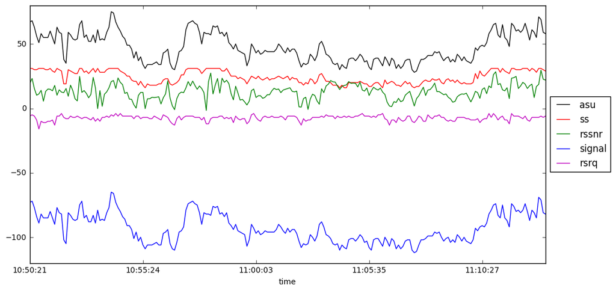

```python
df_nwcell.plot(x=pd.to_datetime(df_nwcell['time']*10**6).map(lambda t: t.strftime('%H:%M:%S')),
               y=['asu', 'ss', 'rssnr', 'signal', 'rsrq'], style=['k-', 'r-', 'g-', 'b-', 'm-'], ylim=(-120, 80),
               figsize=(12, 6)).legend(loc='center left', bbox_to_anchor=(1, 0.5));
```

### Statistika

Kokia yra `Network Cell Info` išmatuotų signalų statistika?

```python
df_nwcell[['asu', 'ss', 'rssnr', 'signal', 'rsrq']].describe()
```

|  | asu | ss | rssnr | signal | rsrq |
| --- | --- | --- | --- | --- | --- |
| count | 229.000000 | 229.000000 | 229.000000 | 229.000000 | 229.000000 |
| mean | 47.174672 | 24.344978 | 12.940611 | -92.825328 | -7.484716 |
| std | 11.135728 | 4.905129 | 6.058542 | 11.135728 | 1.952502 |
| min | 28.000000 | 16.000000 | -1.600000 | -112.000000 | -16.000000 |
| 25% | 38.000000 | 20.000000 | 8.600000 | -102.000000 | -9.000000 |
| 50% | 45.000000 | 23.000000 | 13.000000 | -95.000000 | -7.000000 |
| 75% | 57.000000 | 29.000000 | 17.000000 | -83.000000 | -6.000000 |
| max | 75.000000 | 31.000000 | 29.600000 | -65.000000 | -4.000000 |

### Koreliacija

Ar yra kokia nors priklausomybė tarp atskirų išmatuotų parametrų?

```python
# Koreliacijos koeficientas:
print('signal ~ rssnr: {:.1f} %'.format(df_nwcell['signal'].corr(df_nwcell['rssnr']) * 100))
print('signal ~ ss:    {:.1f} %'.format(df_nwcell['signal'].corr(df_nwcell['ss']) * 100))
```

```
signal ~ rssnr: 52.3 %
signal ~ ss:    96.2 %
```

Kaip koreliacija atrodo grafiškai?

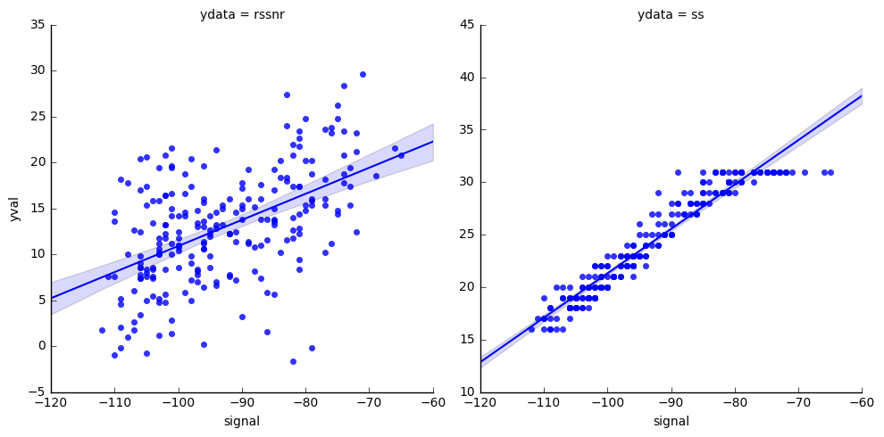

```python
sns.lmplot(x='signal', y='yval', data=corr_res, col='ydata', sharey=False);
```

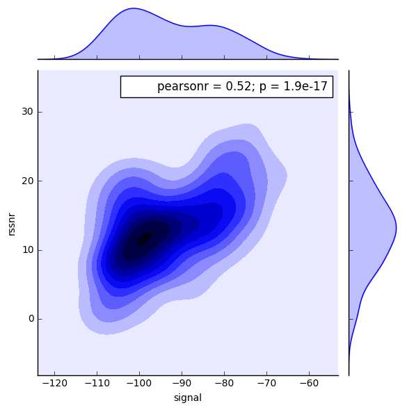

```python
sns.jointplot(x = 'signal', y = 'rssnr', data = df_nwcell, kind='kde');
```

### Kiti matavimų parametrai

Yra ir daugiau išmatuotų parametrų. Kokios jų tarpusavio koreliacijos?

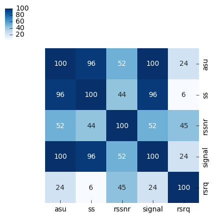

```python
df_nwstats = df_nwcell[['asu', 'ss', 'rssnr', 'signal', 'rsrq']]
corr = df_nwstats.corr().mul(100).astype(int)
sns.clustermap(data=corr, annot=True, fmt='d', cmap='Blues', row_cluster=False, col_cluster=False, figsize=(5, 5));
```

### Parametrų tarpusavio koreliacijos

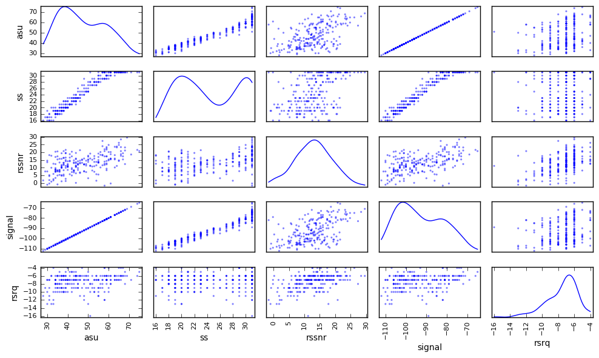

```python
pd.plotting.scatter_matrix(df_nwstats, diagonal='kde', figsize=(10, 6))
plt.tight_layout()
```

### Daugiau informacijos

#### GitHub

- https://github.com/arimvydas/tinklamatis

#### Radijo ryšio signalo matavimo duomenys ir programėlės

- https://opencellid.org/
- http://wilysis.com/networkcellinfo

#### Apie ryšių technologijas

- http://matavimai.rrt.lt/about.html
- https://en.wikipedia.org/wiki/Mobile_phone_signal